# Statistical Tests using Simulation

## Introduction

Theoretical statistical tests involve lot of detailed assumptions, complex formulas and often difficult to interpret. This article uses an alternative approach using simple simulation to arrive at similar results. In most cases, the simulation method makes fewer assumptions about underlying distribution and therefore apply for a larger class of problems.

## One Sample t-test

Consider a coin toss experiment where a potentially biased coin is tossed 30 times resulting in 22 Heads and 8 Tails. Is it a fair coin? This can be answered using a one-sampe t-test with null hypothesis that the coin is fair (`p = 0.5`). And reject the null hypothesis if p-value < 0.05.

The same result can be obtained by simulating a fair coin 30 times and repeating the experiment a large number of times (say 1000). Then compute the proportion of times we see more than 22 Heads out of 1000 experiments. This gives us `P(data|parameter)`.

In both the approaches we reject the null hypothesis and the conclude the coin is biased.

```r
# create 8 tails, 22 heads and shuffle them
coin.toss <- c(rep(0, 8), rep(1, 22))[sample(30)]

OneSample.t.test <- t.test(coin.toss, mu=0.5)
cat("One sample t-test result = ",round(OneSample.t.test$p.value,4))

sim.OneSample.t.test <- replicate(10000, sample(0:1, 30, replace = TRUE)) %>% colSums
cat("\nSimulation result = ",mean(sim.OneSample.t.test >= sum(coin.toss)))
```

```
## One sample t-test result =  0.0081
## Simulation result =  0.008
```

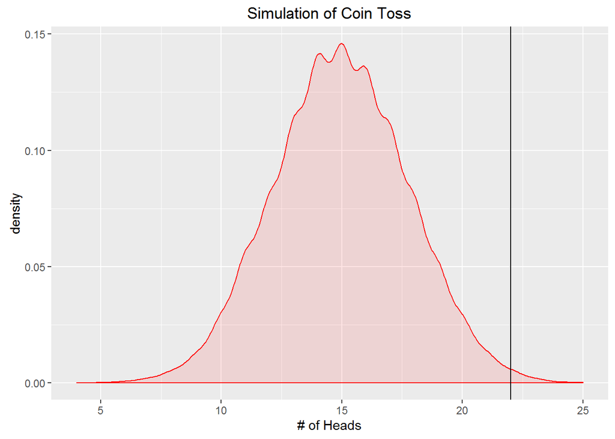

## Two Sample t-test

Consider a weights of two groups where the goal is to check if the difference between the two groups is statistically significant. The built-in `t.test` function can perform Welch two sample t-test where the null hypothesis is that the difference in means between the two groups is 0.

In the simulation approach, the two groups are mixed and suffled to check if the difference is purely random. The experiment is repeated many times.

In both the approaches we fail to reject the null hypothesis and conclude there is no significant difference between two groups.

```r
group1 <- c(84, 72, 57, 46, 63, 76, 99, 91)
group2 <- c(81, 69, 74, 61, 56, 87, 69, 65, 66, 44, 62, 69)

TwoSample.t.test <- t.test(group1, group2, alternative = "two.sided")
cat("Two sample t-test result = ", round(TwoSample.t.test$p.value,4))

sim.TwoSample.t.test <- replicate(10000, {
                          group = c(group1, group2)[sample(length(group1)+length(group2))]; #shuffle
                          mean(head(group, length(group1))) - mean(tail(group, length(group2)))
                        })

# x2 for two.sided
cat("\nSimulation result = ", 2*mean(sim.TwoSample.t.test >= (mean(group1) - mean(group2))))
```

```
## Two sample t-test result =  0.3721
## Simulation result =  0.3228
```

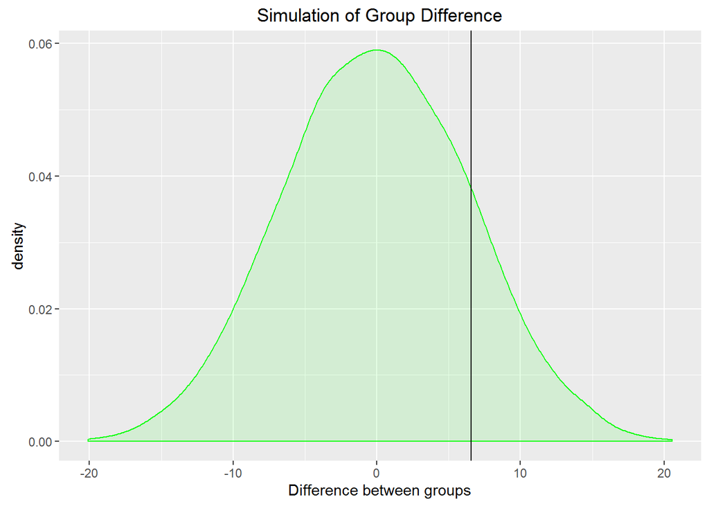

## Chi-Squared Tests

Chi-squared test computes a test statistic which follows Chi-square distribution. Chi-squared test is used for: 1. goodness of fit test - is it a fair dice 2. independence test - is there difference in voting behavior of males vs females

```r
# Goodness of fit Chi-Squared Test
# roll a fair, 4 sided dice 100 times
dice4 <- sample(1:4, 100, replace = TRUE)

chi.statistic = sum((table(dice4) - 25)^2/25)

# Built-in Chi-Squared Test
chi.sq.test = chisq.test(table(dice4), p = rep(0.25, 4))

# Simulate the experiment 10000 times
dice4.sim <- replicate(10000, table(sample(1:4, 100, replace = TRUE)))

# compute chi statistic for each experiment
chi.sim <- colSums((dice4.sim-25)^2/25)

cat("Chi-squared test result = ", chi.sq.test$p.value)
cat("\nSimulation result = ", mean(chi.sim > chi.statistic))
```

```
## Chi-squared test result =  0.7149371
## Simulation result =  0.7058
```

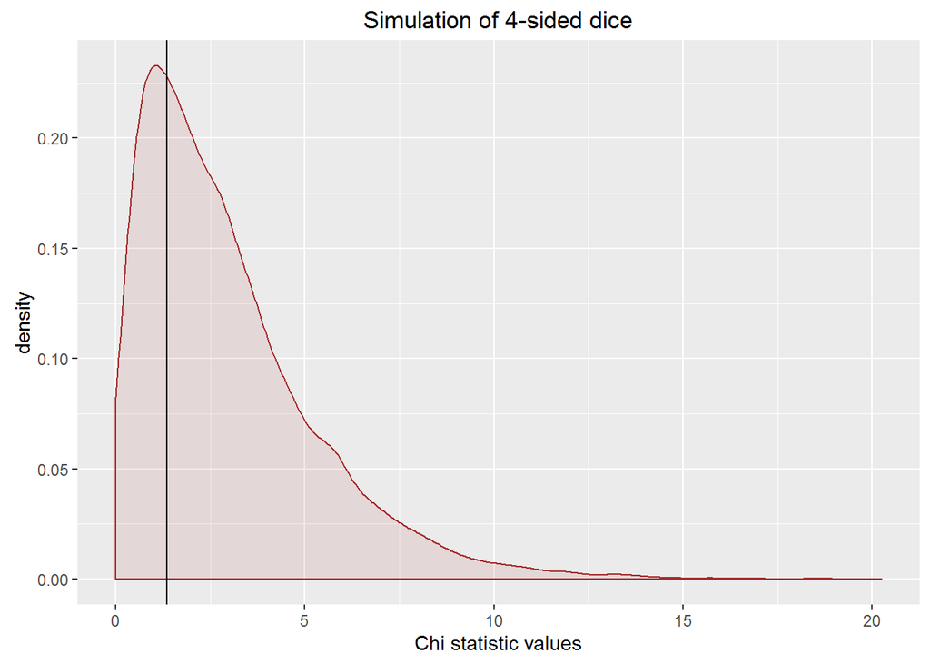

## Sampling Distribution of a Statistic

```r
scores <- c(48, 24, 32, 61, 51, 12, 32, 18, 19, 24, 21, 41, 29, 21, 25, 23, 42, 18, 23, 13)

#cat("Std error of mean = ", std.error(scores))
cat("Std error of mean = ", sd(scores)/sqrt(length(scores)))

boot.samples <- boot(scores, function(x,w) {mean(x[w])}, 1000)$t[,1]
cat("\nStd error of mean (by simulation) = ", sd(boot.samples))
```

```
## Std error of mean =  2.970269
## Std error of mean (by simulation) =  2.968358
```

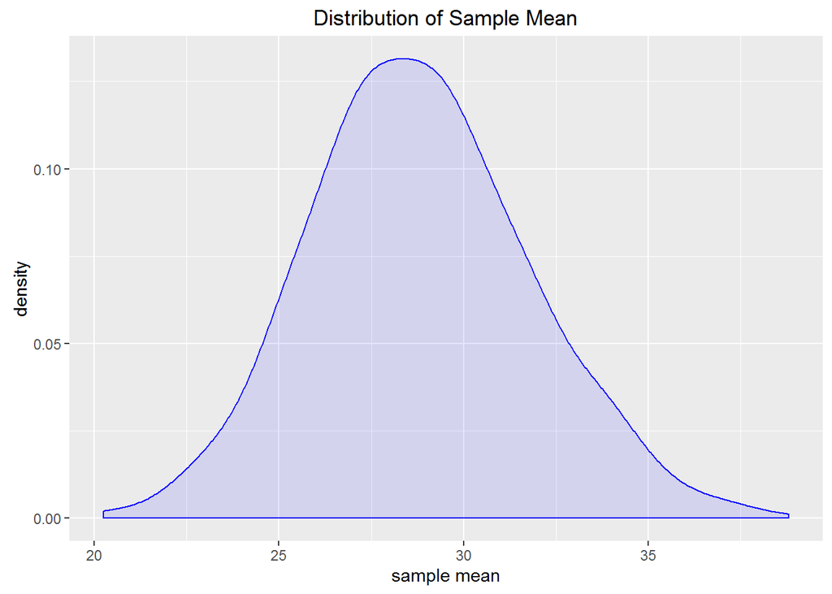